# Introduction to Multilevel Model and Interactions

## Overview

This tutorial covers how the multilevel model can be used to examine within-person associations and how those associations are moderted by between-person differences. Our example is developed using experience sampling data (repeated occasions nested within persons), but also applies to other kinds of nested data.

## Outline

In this session we cover …

A. Preparation and description of variables for use in Multilevel Model  
B. Setting up the Multilevel Model  
C. Using the Mutlilevel Model to Examine Between-Person Differences in Within-Person Associations  
D. Plotting and Probing Interactions

The overall set-up of the models follows Bolger & Laurenceau (2013) Chapters 4 and 5.

#### Prelim - Loading libraries used in this script.

```r
if (!require(pacman)) { install.packages("pacman"); library(pacman) }
p_load(
  backports, # to revive the isFALSE() function for sim_slopes()
  effects, # for probing interactions
  ggplot2, # for data visualization
  interactions, # for probing/plotting interactions
  lme4, # for multilevel models
  lmerTest, # for p-values
  psych, # for describing the data
  plyr # for data manipulation
)
```

#### Prelim - Reading in Repeated Measures Data

Our example makes use of the person-level and day-level (EMA-type) AMIB data files, publically available data from an experience sampling study. Information about the data can be found on the QuantDev website.

We make use of three variables:

Outcome: *daily negative affect* (**continuous**), the `negaff` variable in the day-level data file;

Time-varying Predictor: *daily stress*, a `stress` variable obtained through reverse coding of `pss` in the day-level data file;

Person-level Predictor/Moderator: trait *neuroticism*, the `bfi_n` variable in the person-level data file.

Loading person-level file (*N* = 190) and subsetting to variables of interest

```r
#set filepath for data file
filepath <- "https://quantdev.ssri.psu.edu/sites/qdev/files/AMIBshare_persons_2019_0501.csv"

#read in the .csv file using the url() function
AMIB_persons <- read.csv(file=url(filepath),header=TRUE)

#subsetting to variables of interest
AMIB_persons <- AMIB_persons[ ,c("id","bfi_n")]
```

Loading day-level file (*T* = 8) and subsetting to variables of interest.

```r
#set filepath for data file
filepath <- "https://quantdev.ssri.psu.edu/sites/qdev/files/AMIBshare_daily_2019_0501.csv"

#read in the .csv file using the url() function
AMIB_daily <- read.csv(file=url(filepath),header=TRUE)

#subsetting to variables of interest
AMIB_daily <- AMIB_daily[ ,c("id","day","negaff","pss")]
```

## A. Preparation and description of variables for use in Multilevel Model

In this example data are prepared through some recoding (idiosyncratic for this data set), and separation of time-varying predictor variables into between-person and within-person components (typical for all multilevel analysis)

**Data Recoding**

Reverse code `pss` into a new `stress` variable where higher values indicate higher perceived stress.

```r
#reverse coding the pss variable into a new stress variable
AMIB_daily$stress <- 4 - AMIB_daily$pss

#describing new variable
describe(AMIB_daily$stress)
```

```
##    vars    n mean   sd median trimmed  mad min max range skew kurtosis
## X1    1 1445 1.39 0.68   1.25    1.36 0.74   0   4     4 0.35     0.13
##      se
## X1 0.02
```

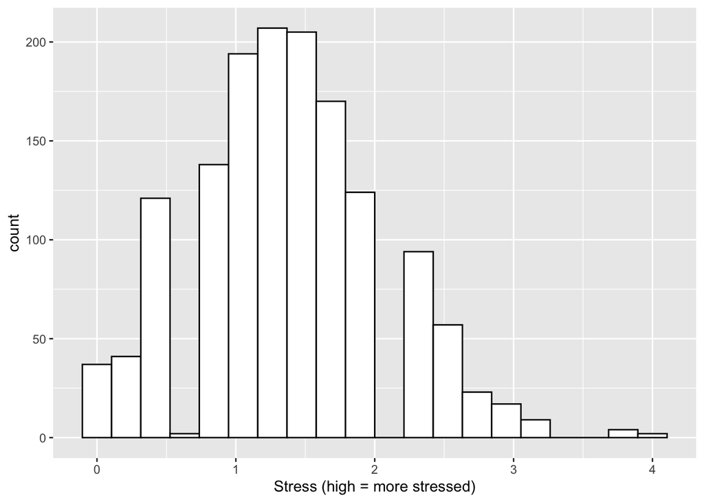

```r
#histogram
ggplot(data=AMIB_daily, aes(x=stress)) +
  geom_histogram(fill="white", color="black",bins=20) +
  labs(x = "Stress (high = more stressed)")
```

**Data Preparation (between- and within- components)**

We now split the time-varying predictor into “trait” (between-person differences) and “state” (within-person deviations) components. Specifically, the daily variable `stress` is split into two varaibles: `stress_trait` is the sample-mean centered between-person component, and `stress_state` is the person-centered within-person component.

Although not formally needed, we do this for all the time-varying variables (predictors, outcomes) for easier plotting later.

Making trait variables.

```r
#calculating intraindividual means
#Alternative approach using dplyr
    #AMIB_imeans <- AMIB_daily %>%
    #               group_by(id) %>%
    #               summarize(stress_trait=mean(stress, na.rm=TRUE))

AMIB_imeans <- ddply(AMIB_daily, "id", summarize,
                       stress_trait = mean(stress, na.rm=TRUE),
                       negaff_trait = mean(negaff, na.rm=TRUE))
describe(AMIB_imeans)
```

```
##              vars   n   mean     sd median trimmed    mad    min    max
## id              1 190 318.29 130.44 321.50  318.99 151.23 101.00 532.00
## stress_trait    2 190   1.40   0.48   1.41    1.39   0.51   0.19   2.56
## negaff_trait    3 190   2.48   0.73   2.41    2.43   0.72   1.11   5.09
##               range  skew kurtosis   se
## id           431.00 -0.04    -1.09 9.46
## stress_trait   2.38 -0.04    -0.23 0.03
## negaff_trait   3.98  0.68     0.45 0.05
```

```r
#merging into person-level file
AMIB_persons <- merge(AMIB_persons, AMIB_imeans, by="id")

#make centered versions of the person-level scores
AMIB_persons$bfi_n_c <- scale(AMIB_persons$bfi_n,center=TRUE,scale=FALSE)
AMIB_persons$stress_trait_c <- scale(AMIB_persons$stress_trait,center=TRUE,scale=FALSE)

#describe person-level data
describe(AMIB_persons)
```

```
##                vars   n   mean     sd median trimmed    mad    min    max
## id                1 190 318.29 130.44 321.50  318.99 151.23 101.00 532.00
## bfi_n             2 190   2.98   0.96   3.00    3.00   1.48   1.00   5.00
## stress_trait      3 190   1.40   0.48   1.41    1.39   0.51   0.19   2.56
## negaff_trait      4 190   2.48   0.73   2.41    2.43   0.72   1.11   5.09
## bfi_n_c           5 190   0.00   0.96   0.02    0.02   1.48  -1.98   2.02
## stress_trait_c    6 190   0.00   0.48   0.01    0.00   0.51  -1.21   1.17
##                 range  skew kurtosis   se
## id             431.00 -0.04    -1.09 9.46
## bfi_n            4.00 -0.09    -0.82 0.07
## stress_trait     2.38 -0.04    -0.23 0.03
## negaff_trait     3.98  0.68     0.45 0.05
## bfi_n_c          4.00 -0.09    -0.82 0.07
## stress_trait_c   2.38 -0.04    -0.23 0.03
```

Making state variables in long data (as deviations from uncentered trait variable).

```r
#merging person-level data into daily data
daily_long <- merge(AMIB_daily,AMIB_persons,by="id")

#calculating state variables
daily_long$stress_state <- daily_long$stress - daily_long$stress_trait
daily_long$negaff_state <- daily_long$negaff - daily_long$negaff_trait

#describing data
describe(daily_long)
```

```
##                vars    n   mean     sd median trimmed    mad    min    max
## id                1 1458 322.53 129.08 324.00  324.20 151.23 101.00 532.00
## day               2 1458   3.48   2.30   3.00    3.47   2.97   0.00   7.00
## negaff            3 1441   2.45   1.04   2.20    2.34   1.04   1.00   6.90
## pss               4 1445   2.61   0.68   2.75    2.64   0.74   0.00   4.00
## stress            5 1445   1.39   0.68   1.25    1.36   0.74   0.00   4.00
## bfi_n             6 1458   2.97   0.96   3.00    2.98   1.48   1.00   5.00
## stress_trait      7 1458   1.39   0.47   1.41    1.39   0.51   0.19   2.56
## negaff_trait      8 1458   2.45   0.71   2.38    2.41   0.67   1.11   5.09
## bfi_n_c           9 1458  -0.01   0.96   0.02    0.00   1.48  -1.98   2.02
## stress_trait_c   10 1458  -0.01   0.47   0.01   -0.01   0.51  -1.21   1.17
## stress_state     11 1445   0.00   0.49  -0.03   -0.02   0.46  -1.75   2.12
## negaff_state     12 1441   0.00   0.76  -0.10   -0.04   0.63  -3.62   3.16
##                 range  skew kurtosis   se
## id             431.00 -0.07    -1.06 3.38
## day              7.00  0.01    -1.24 0.06
## negaff           5.90  0.96     0.77 0.03
## pss              4.00 -0.35     0.13 0.02
## stress           4.00  0.35     0.13 0.02
## bfi_n            4.00 -0.08    -0.79 0.03
## stress_trait     2.38 -0.08    -0.21 0.01
## negaff_trait     3.98  0.66     0.52 0.02
## bfi_n_c          4.00 -0.08    -0.79 0.03
## stress_trait_c   2.38 -0.08    -0.21 0.01
## stress_state     3.88  0.36     0.79 0.01
## negaff_state     6.78  0.50     1.70 0.02
```

Great! Now the data are all prepared as needed.

## B. Setting up the Multilevel Model

**Set-up for basic multilevel model with continuous outcome**

Outlining the substantive inquiry.

We *define* **stress reactivty** (a person-level *dynamic characteristic*; Ram & Gerstorf, 2009) as the extent to which an individual’s daily negative affect is related to daily stress. That is, *stress reactivity* is the *within-person association* between daily negative affect and daily stress. Lets examine some of our prepared data to see what *stress reactivity* looks like.

Plotting within-person associations for a subset of individuals.

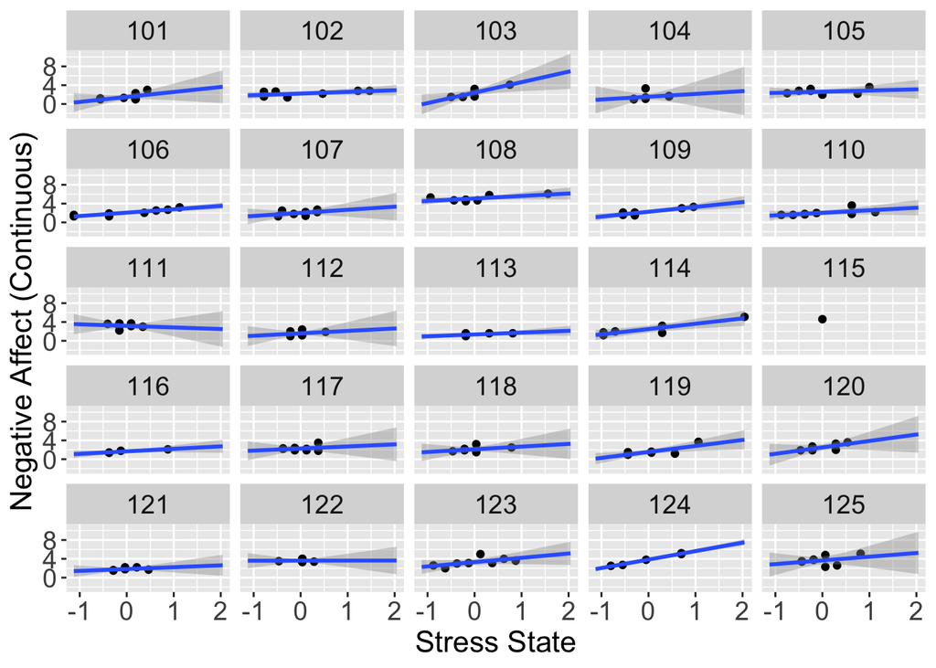

```r
#faceted plot
ggplot(data=daily_long[which(daily_long$id <= 125),], aes(x=stress_state,y=negaff)) +
  geom_point() +
  stat_smooth(method="lm", fullrange=TRUE) +
  xlab("Stress State") + ylab("Negative Affect (Continuous)") +
  facet_wrap( ~ id) +
  theme(axis.title=element_text(size=16),
        axis.text=element_text(size=14),
        strip.text=element_text(size=14))
```

To constrain the regression line within the range of stress scores for each person (instead of extrapolating to the full range of stress scores), specify `fullrange=FALSE` in the `stat_smooth` layer above.

From the panel of plots we get a sense that individuals’ *negative affect* is higher on days where their *stress* is higher, but to a different extent for each person. These differences in *stress reactivity* are indicated by differences in the slope of the regression lines.

Our substantive interest is in describing individual differences in *stress reactivity* and determining if those differences are related to differences in *neuroticism*.

The basic linear multilevel model is written as

$$y_{it} = \beta_{0i} + \beta_{1i}x_{it} + e_{it}$$
where the time-varying outcome variable, $y_{it}$ (*negative affect*) is modeled as a function of a person-specific intercept, $\beta_{0i}$, a person-specific slope, $\beta_{1i}$, that captures the within-person association of interest (in our case *stress reactivity*), and residual error, $e_{it}$. The person-specific intercepts and slopes are modeled in turn as

$$\beta_{0i} = \gamma_{00} + \gamma_{01}z_{i} + u_{0i}$$
$$\beta_{1i} = \gamma_{10} + \gamma_{11}z_{i} + u_{1i}$$

Importantly,
$$e_{it} \tilde{} N(0,\mathbf{R})$$
, and
$$\mathbf{U}_{i} \tilde{} MVN(0,\mathbf{G})$$

$$\mathbf{R} = \mathbf{I}\sigma^{2}_{e}$$
, where where $I$ is the identity matrix (diagonal matrix of 1s) and $\sigma^{2}_{e}$ is the residual (within-person) variance.

$$\mathbf{G} = \left[\begin{array}
{rr}
\sigma^{2}_{u0} & \sigma_{u0u1} \\
\sigma_{u1u0} & \sigma^{2}_{u1}
\end{array}\right]$$

Together, the full set of parameters provide a parsimonious description of the data that allows for inference about within-person associations and between-person differeneces in those associations.

## B. Setting up the Multilevel Model

Now that we have defined the dynamic characteristic of interest - stress reactivity - we can operationalize it using the multilevel model.

We make use of the `lme4` package for fitting mixed effects models, and some supplmentary packages: `lmerTest` provides tools for obtaining p-values; `effects` provides tools for calculating and plotting model-based predictions; and `interactions` provides tools for plotting and probing interactions.

The `lmer()` function fits the MLMs The `data` argument specifies the data sources The `na.action` argument specifies what to do with missing data

To start, we often fit an *unconditional means model* that provides us information about how much of the total variance in the outcome varaible is within-person variance and how much is between-person variance.

Fitting the unconditional means model.

```r
#unconditional means model
model0_fit <- lmer(formula = negaff ~ 1 + (1|id),
              data=daily_long,
              na.action=na.exclude)
summary(model0_fit)
```

```
## Linear mixed model fit by REML. t-tests use Satterthwaite's method [
## lmerModLmerTest]
## Formula: negaff ~ 1 + (1 | id)
##    Data: daily_long
##
## REML criterion at convergence: 3833.5
##
## Scaled residuals:
##     Min      1Q  Median      3Q     Max
## -3.8739 -0.6123 -0.1608  0.4658  3.9394
##
## Random effects:
##  Groups   Name        Variance Std.Dev.
##  id       (Intercept) 0.4270   0.6535
##  Residual             0.6627   0.8141
## Number of obs: 1441, groups:  id, 190
##
## Fixed effects:
##              Estimate Std. Error        df t value Pr(>|t|)
## (Intercept)   2.46368    0.05229 185.80793   47.12   <2e-16 ***
## ---
## Signif. codes:  0 '***' 0.001 '**' 0.01 '*' 0.05 '.' 0.1 ' ' 1
```

We extract the random effects with the VarCorr() function:

```r
VarCorr(model0_fit)
```

```
##  Groups   Name        Std.Dev.
##  id       (Intercept) 0.65347
##  Residual             0.81408
```

And then compute the intra-class correlation (ICC) as the ratio of the random intercept variance (between-person) to the total variance, defined as the sum of the random intercept variance and residual variance (between + within). Specifically,
$$ICC_{between} = \frac{\sigma^{2}_{u0}}{\sigma^{2}_{u0} + \sigma^{2}_{e}}$$

Calculating the ICC.

```r
RandomEffects <- as.data.frame(VarCorr(model0_fit))
RandomEffects
```

```
##        grp        var1 var2      vcov     sdcor
## 1       id (Intercept) <NA> 0.4270294 0.6534749
## 2 Residual        <NA> <NA> 0.6627260 0.8140798
```

Next, compute the ICC. It is the ratio of the random intercept variance (between-person var) over the total variance (between + within var):

```r
ICC_between <- RandomEffects[1,4]/(RandomEffects[1,4]+RandomEffects[2,4])
ICC_between
```

```
## [1] 0.391858
```

*From the unconditional means model, the ICC was calculated, which indicated that of the total variance in negative affect, 39.19% is attributable to between-person variation whereas 60.81% is attributatable to within-person variation.*

This means there is a good portion of within-person variance to model using time-varying predictor.

## C. Using the Mutlilevel Model to Examine Between-Person Differences in Within-Person Associations

OK - let’s add the predictor, which was split into two components `stress_trait` (between-person component) and `stress_state` (within-person component), that latter gives us possibility to quantify each individual’s *stress reactivity*. Note that we also include `day` as a time-varying predictor, but simply as a control variable to account for any systematic time trends in the data.

```r
# fit model
model1_fit <- lmer(formula = negaff ~ 1 + day + stress_trait_c +
                      stress_state + stress_state:stress_trait_c +
                      (1 + stress_state|id),
                    data=daily_long,
                    na.action=na.exclude)
summary(model1_fit)
```

```
## Linear mixed model fit by REML. t-tests use Satterthwaite's method [
## lmerModLmerTest]
## Formula:
## negaff ~ 1 + day + stress_trait_c + stress_state + stress_state:stress_trait_c +
##     (1 + stress_state | id)
##    Data: daily_long
##
## REML criterion at convergence: 3162.4
##
## Scaled residuals:
##     Min      1Q  Median      3Q     Max
## -3.5368 -0.6127 -0.0729  0.5093  4.4164
##
## Random effects:
##  Groups   Name         Variance Std.Dev. Corr
##  id       (Intercept)  0.2135   0.4621
##           stress_state 0.1257   0.3546   0.53
##  Residual              0.4038   0.6355
## Number of obs: 1438, groups:  id, 190
##
## Fixed effects:
##                               Estimate Std. Error         df t value
## (Intercept)                  2.695e+00  4.583e-02  3.922e+02  58.806
## day                         -6.580e-02  7.552e-03  1.250e+03  -8.713
## stress_trait_c               1.038e+00  7.946e-02  1.859e+02  13.067
## stress_state                 7.647e-01  4.561e-02  1.664e+02  16.765
## stress_trait_c:stress_state  1.550e-01  9.780e-02  1.584e+02   1.585
##                             Pr(>|t|)
## (Intercept)                   <2e-16 ***
## day                           <2e-16 ***
## stress_trait_c                <2e-16 ***
## stress_state                  <2e-16 ***
## stress_trait_c:stress_state    0.115
## ---
## Signif. codes:  0 '***' 0.001 '**' 0.01 '*' 0.05 '.' 0.1 ' ' 1
##
## Correlation of Fixed Effects:
##             (Intr) day    strs__ strss_
## day         -0.569
## strss_trt_c  0.004  0.007
## stress_stat  0.216  0.012  0.002
## strss_tr_:_  0.034 -0.057  0.268 -0.118
```

```r
# save predicted scores
daily_long$pred_m1 <- predict(model1_fit)
```

**Interpreting and Plotting the Results**

The results indicate that there is an association between perceived stress and negative affect, both across persons (between-person association) and within persons (average within-person association). These are described by the Fized Effects parameters.

We can also get confidence intervals for the fixed and random effects. Depending on model complexity, the `confint()` can sometimes take a while to run.

```r
# Get confidence intervals for both fixed and random effects
confint(model1_fit)
```

```
## Computing profile confidence intervals ...
```

```
##                                   2.5 %      97.5 %
## .sig01                       0.40389453  0.52247647
## .sig02                       0.27635941  0.77129774
## .sig03                       0.25230528  0.45069365
## .sigma                       0.60962953  0.66244318
## (Intercept)                  2.60530434  2.78468855
## day                         -0.08058845 -0.05099125
## stress_trait_c               0.88249222  1.19390741
## stress_state                 0.67339999  0.85449743
## stress_trait_c:stress_state -0.03788636  0.34703328
```

The labels for the random effects are not entirely intuitive (e.g., `sig01`, `sig02`, `sig03`, `sigma`) - especially for models with several random effects. So, need to check carefully how to interpret the output.

In the above output:

- sig01 = random effect CI for random intercept (given in SD units - need to square the values if you want the variances)
- sig02 = correlation between the random intercept and random slope (for stress_state)
- sig03 = random effect CI for random slope (stress_state; given in SD units - need to square the values if you want the variances)
- sigma = residual error CI (given in SD units - need to square the values if you want the variances)

In general, the output given from the `confint()` will give you the confidence intervals (given in SD units - will need to square these values if you want the variances) for the first random effect (e.g., the random intercept). Then it will give you the correlations between that random effect and all other random effects it is correlated with. The next row of CI values will correspond to the second random effect (e.g., the random slope for stress_state), with the following rows pertaining to all random effects it is correlated with (but not include any correlations already given - because for example, the correlation for the random intercept and random slope for stress_state was already given). The last row pertaining to random effects is always called `sigma`, and pertains to the residual error (given in SD units - will need to square these values if you want the variances).

Next, we can plot between-person associations.

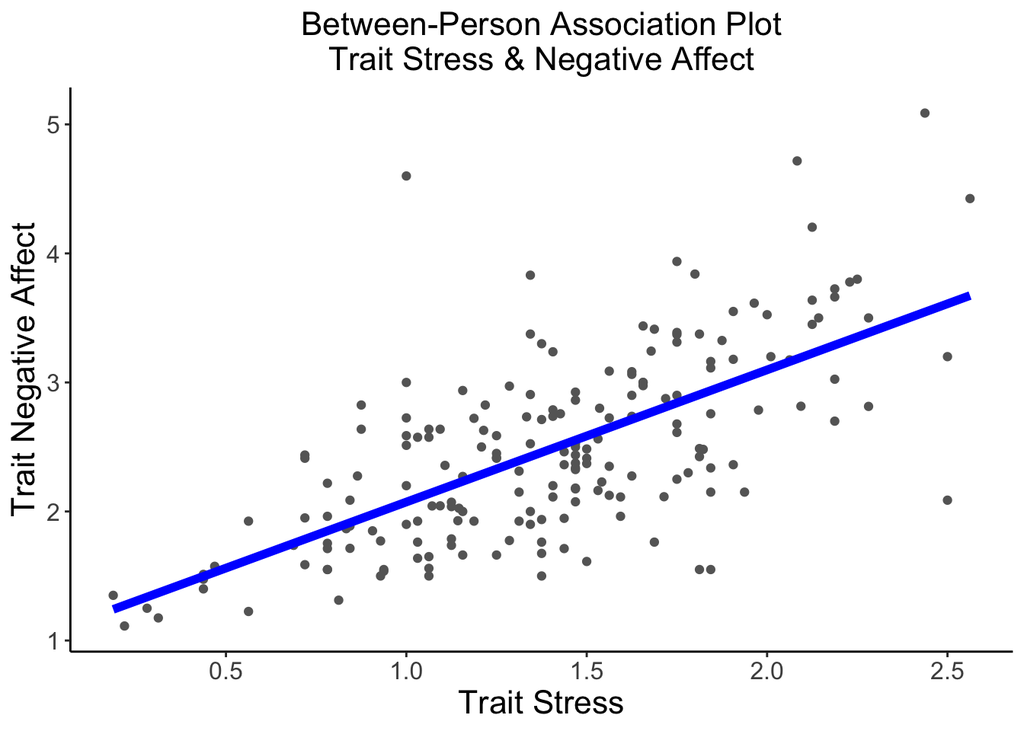

```r
ggplot(data=AMIB_imeans, aes(x=stress_trait, y=negaff_trait, group=factor(id)), legend=FALSE) +
  geom_point(colour="gray40") +
  geom_smooth(aes(group=1), method=lm, se=FALSE, fullrange=FALSE, lty=1, size=2, color="blue") +
  xlab("Trait Stress") + ylab("Trait Negative Affect") +
  theme_classic() +
  theme(axis.title=element_text(size=16),
        axis.text=element_text(size=12),
        plot.title=element_text(size=16, hjust=.5)) +
  ggtitle("Between-Person Association Plot\nTrait Stress & Negative Affect")
```

Note that the plot is not actually using the model output - so it is just an approximation of the exact model (using geom_smooth embedded within ggplot). However, it is a very useful display.

Plotting predicted within-person associations.

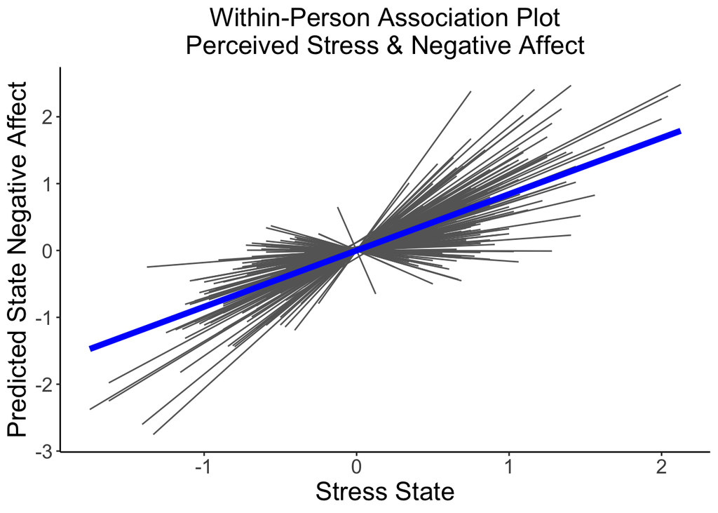

```r
ggplot(data=daily_long, aes(x=stress_state, y=negaff_state, group=factor(id), colour="gray"), legend=FALSE) +
  geom_smooth(method=lm, se=FALSE, fullrange=FALSE, lty=1, size=.5, color="gray40") +
  geom_smooth(aes(group=1), method=lm, se=FALSE, fullrange=FALSE, lty=1, size=2, color="blue") +
  xlab("Stress State") + ylab("Predicted State Negative Affect") +
  theme_classic() +
  theme(axis.title=element_text(size=18),
        axis.text=element_text(size=14),
        plot.title=element_text(size=18, hjust=.5)) +
  ggtitle("Within-Person Association Plot\nPerceived Stress & Negative Affect")
```

Note that the plot is not actually using the model output - so it is just an approximation of the exact model (using geom_smooth with *state* scores embedded within ggplot). However, it is a very useful display.

**Adding another Person-level Predictor**

We now add trait neuroticism to the model, to see if and how between-person differences in neuroticism are related to *stress reactivity*.

Running the expanded model.

```r
# fit model
model2_fit <- lmer(formula = negaff ~ 1 + day + stress_trait_c +
                      bfi_n_c + stress_trait_c:bfi_n_c +
                      stress_state + stress_state:stress_trait_c +
                      stress_state:bfi_n_c + stress_state:stress_trait_c:bfi_n_c +
                      (1 + stress_state|id),
                    data=daily_long,
                    na.action=na.exclude)
#Look at results
summary(model2_fit)
```

```
## Linear mixed model fit by REML. t-tests use Satterthwaite's method [
## lmerModLmerTest]
## Formula:
## negaff ~ 1 + day + stress_trait_c + bfi_n_c + stress_trait_c:bfi_n_c +
##     stress_state + stress_state:stress_trait_c + stress_state:bfi_n_c +
##     stress_state:stress_trait_c:bfi_n_c + (1 + stress_state |      id)
##    Data: daily_long
##
## REML criterion at convergence: 3161.8
##
## Scaled residuals:
##     Min      1Q  Median      3Q     Max
## -3.4271 -0.6011 -0.0749  0.5045  4.4732
##
## Random effects:
##  Groups   Name         Variance Std.Dev. Corr
##  id       (Intercept)  0.1955   0.4422
##           stress_state 0.1238   0.3518   0.51
##  Residual              0.4040   0.6356
## Number of obs: 1438, groups:  id, 190
##
## Fixed effects:
##                                       Estimate Std. Error         df
## (Intercept)                          2.690e+00  4.556e-02  3.943e+02
## day                                 -6.545e-02  7.572e-03  1.247e+03
## stress_trait_c                       9.695e-01  7.878e-02  1.835e+02
## bfi_n_c                              1.543e-01  3.917e-02  1.809e+02
## stress_state                         7.687e-01  4.682e-02  1.673e+02
## stress_trait_c:bfi_n_c               3.715e-02  7.833e-02  1.824e+02
## stress_trait_c:stress_state          1.254e-01  1.015e-01  1.692e+02
## bfi_n_c:stress_state                 7.595e-02  4.845e-02  1.549e+02
## stress_trait_c:bfi_n_c:stress_state -3.167e-02  1.024e-01  1.722e+02
##                                     t value Pr(>|t|)
## (Intercept)                          59.053  < 2e-16 ***
## day                                  -8.644  < 2e-16 ***
## stress_trait_c                       12.306  < 2e-16 ***
## bfi_n_c                               3.938 0.000117 ***
## stress_state                         16.418  < 2e-16 ***
## stress_trait_c:bfi_n_c                0.474 0.635849
## stress_trait_c:stress_state           1.235 0.218473
## bfi_n_c:stress_state                  1.568 0.119006
## stress_trait_c:bfi_n_c:stress_state  -0.309 0.757566
## ---
## Signif. codes:  0 '***' 0.001 '**' 0.01 '*' 0.05 '.' 0.1 ' ' 1
##
## Correlation of Fixed Effects:
##             (Intr) day    strs__ bf_n_c strss_ st__:__ st__:_ bf__:_
## day         -0.576
## strss_trt_c  0.003  0.005
## bfi_n_c     -0.008  0.007 -0.224
## stress_stat  0.204  0.004  0.000  0.001
## strss_t_:__ -0.179  0.008  0.008  0.040 -0.054
## strss_tr_:_  0.042 -0.073  0.248 -0.056 -0.087  0.003
## bf_n_c:str_ -0.033  0.058 -0.058  0.258  0.016  0.009  -0.244
## strs__:__:_ -0.061  0.032  0.004  0.008 -0.233  0.243  -0.103 -0.059
```

```r
# save predicted scores
daily_long$pred_m2 <- predict(model2_fit)
```

## D. Plotting and Probing Interactions

**Probing and Plotting the Interaction**

The moderation is not significant. However, if it were, we would want to plot and probe the interaction term, specifically the `stress_state:bfi_n_c` term.

We can use the `effect` function.  
We examine what the effect is as various levels of the predictors. Standard practice is to use +1 and -1 SD.

```r
#xlevels = is the list of values that we want to evaluate at.
#obtaining the standard deviation of the between-person moderator
describe(daily_long$bfi_n_c)
```

```
##    vars    n  mean   sd median trimmed  mad   min  max range  skew
## X1    1 1458 -0.01 0.96   0.02       0 1.48 -1.98 2.02     4 -0.08
##    kurtosis   se
## X1    -0.79 0.03
```

```r
#obtaining the standard deviation of the time-varying predictor
describe(daily_long$stress_state)
```

```
##    vars    n mean   sd median trimmed  mad   min  max range skew kurtosis
## X1    1 1445    0 0.49  -0.03   -0.02 0.46 -1.75 2.12  3.88 0.36     0.79
##      se
## X1 0.01
```

```r
#calculate effect
effects_model2 <- effect(term="bfi_n_c*stress_state", mod=model2_fit,
                         xlevels=list(bfi_n_c=c(-0.96, +0.96), stress_state=c(-0.49,+0.49)))
```

```
## NOTE: bfi_n_c:stress_state is not a high-order term in the model
```

```r
summary(effects_model2)
```

```
##
##  bfi_n_c*stress_state effect
##        stress_state
## bfi_n_c    -0.49     0.49
##   -0.96 1.964451 2.644774
##   0.96  2.188158 3.011999
##
##  Lower 95 Percent Confidence Limits
##        stress_state
## bfi_n_c    -0.49     0.49
##   -0.96 1.858007 2.510682
##   0.96  2.080616 2.876434
##
##  Upper 95 Percent Confidence Limits
##        stress_state
## bfi_n_c    -0.49     0.49
##   -0.96 2.070894 2.778866
##   0.96  2.295700 3.147563
```

Everything we need is in there!

We can convert to a data frame and plot it!

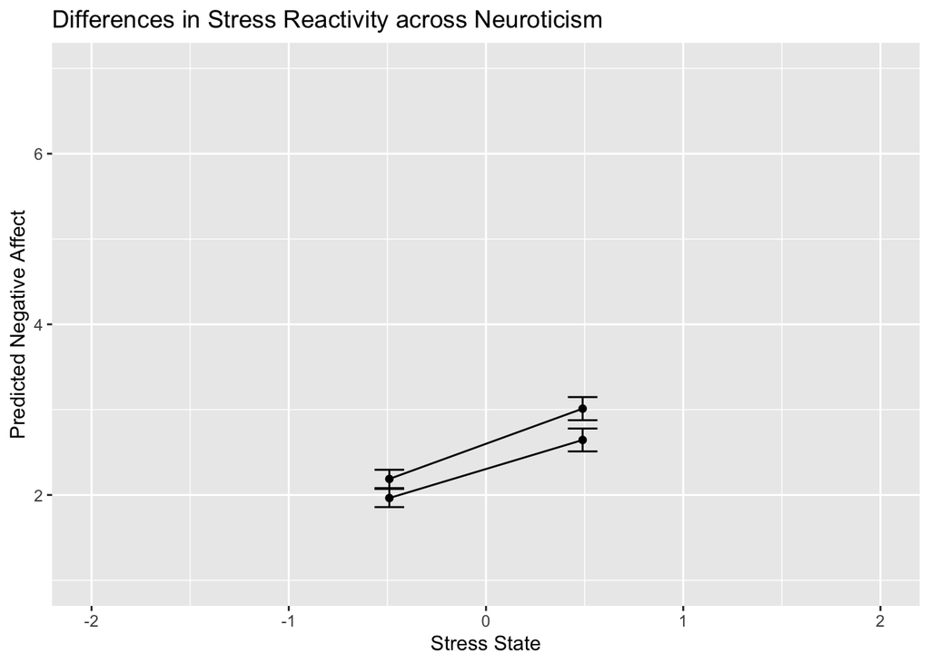

```r
#convert to dataframe
effectsdata <- as.data.frame(effects_model2)
#plotting the effect evaluation (with standard error ribbon)
ggplot(data=effectsdata, aes(x=stress_state, y=fit, group=bfi_n_c), legend=FALSE) +
  geom_point() +
  geom_line() +
  #geom_ribbon(aes(ymin=lower, ymax=upper), alpha=.3) +
  geom_errorbar(aes(ymin=lower, ymax=upper), width=.15) +
  xlab("Stress State") + xlim(-2,2) +
  ylab("Predicted Negative Affect") + ylim(1,7) +
  ggtitle("Differences in Stress Reactivity across Neuroticism")
```

Note that the non-significant interaction appears as two practically parallel lines.

**Johnson-Neyman Technique**

Let’s go a bit further …

We would like to identify the range of values of the moderator at which the within-person slope is significant. Formally, the *Johnson-Neyman* technique is used to probe significant interactions in order to determine for what values of the moderator the focal predictor is significantly related to the outcome - i.e., to identify the *region of significance*. This is quickly becoming standard practice in reporting about interactions in multilevel models.

In our case, we are interested to know the range of *neuroticism* scores at which we would expect individuals to have significant *stress reactivity* (within-person association between daily stress and daily negative affect).

We make use of the `johnson-neyman()` function in the `interactions` package. Note that the `backports` package may also be needed to get a deprecated `isFALSE()` function that this package uses.

Also, when using the `interactions` package we need to do a little data formatting (to make sure that all variables are vectors), and to run the model using lmer() without the lmerTest() overlay (to obtain a merMod object).

Fixing data.

```r
#check for embedded matrices
str(daily_long)
```

```
## 'data.frame':    1458 obs. of  14 variables:
##  $ id            : int  101 101 101 101 101 101 101 101 102 102 ...
##  $ day           : int  0 1 2 3 4 5 6 7 0 1 ...
##  $ negaff        : num  3 2.3 1 1.3 1.1 1 1.2 1.1 1.4 1.6 ...
##  $ pss           : num  2.5 2.75 3.5 3 2.75 2.75 3.5 2.75 3.5 4 ...
##  $ stress        : num  1.5 1.25 0.5 1 1.25 1.25 0.5 1.25 0.5 0 ...
##  $ bfi_n         : num  2 2 2 2 2 2 2 2 2 2 ...
##  $ stress_trait  : num  1.06 1.06 1.06 1.06 1.06 ...
##  $ negaff_trait  : num  1.5 1.5 1.5 1.5 1.5 ...
##  $ bfi_n_c       : num [1:1458, 1] -0.982 -0.982 -0.982 -0.982 -0.982 ...
##  $ stress_trait_c: num [1:1458, 1] -0.333 -0.333 -0.333 -0.333 -0.333 ...
##  $ stress_state  : num  0.4375 0.1875 -0.5625 -0.0625 0.1875 ...
##  $ negaff_state  : num  1.5 0.8 -0.5 -0.2 -0.4 ...
##  $ pred_m1       : num  2.12 1.91 1.4 1.63 1.71 ...
##  $ pred_m2       : num  2.1 1.89 1.39 1.61 1.69 ...
```

```r
#fixing a few variables that were matrices to be vectors
daily_long$bfi_n_c <- as.vector(daily_long$bfi_n_c)
daily_long$stress_trait_c <- as.vector(daily_long$stress_trait_c)
```

Specify and fit model as specific `lme4::lmer` to get `merMod` object (rather than a `lmerModLmerTest` object).

```r
# fit model
model2a_fit <- lme4::lmer(formula = negaff ~ 1 + day + stress_trait_c +
                      bfi_n_c + stress_trait_c:bfi_n_c +
                      stress_state + stress_state:stress_trait_c +
                      stress_state:bfi_n_c + stress_state:stress_trait_c:bfi_n_c +
                      (1 + stress_state|id),
                    data=daily_long,
                    na.action=na.exclude)

# Look at results
summary(model2a_fit)
```

```
## Linear mixed model fit by REML ['lmerMod']
## Formula:
## negaff ~ 1 + day + stress_trait_c + bfi_n_c + stress_trait_c:bfi_n_c +
##     stress_state + stress_state:stress_trait_c + stress_state:bfi_n_c +
##     stress_state:stress_trait_c:bfi_n_c + (1 + stress_state |      id)
##    Data: daily_long
##
## REML criterion at convergence: 3161.8
##
## Scaled residuals:
##     Min      1Q  Median      3Q     Max
## -3.4271 -0.6011 -0.0749  0.5045  4.4732
##
## Random effects:
##  Groups   Name         Variance Std.Dev. Corr
##  id       (Intercept)  0.1955   0.4422
##           stress_state 0.1238   0.3518   0.51
##  Residual              0.4040   0.6356
## Number of obs: 1438, groups:  id, 190
##
## Fixed effects:
##                                      Estimate Std. Error t value
## (Intercept)                          2.690416   0.045560  59.053
## day                                 -0.065452   0.007572  -8.644
## stress_trait_c                       0.969537   0.078785  12.306
## bfi_n_c                              0.154266   0.039170   3.938
## stress_state                         0.768705   0.046821  16.418
## stress_trait_c:bfi_n_c               0.037151   0.078327   0.474
## stress_trait_c:stress_state          0.125402   0.101524   1.235
## bfi_n_c:stress_state                 0.075952   0.048450   1.568
## stress_trait_c:bfi_n_c:stress_state -0.031668   0.102428  -0.309
##
## Correlation of Fixed Effects:
##             (Intr) day    strs__ bf_n_c strss_ st__:__ st__:_ bf__:_
## day         -0.576
## strss_trt_c  0.003  0.005
## bfi_n_c     -0.008  0.007 -0.224
## stress_stat  0.204  0.004  0.000  0.001
## strss_t_:__ -0.179  0.008  0.008  0.040 -0.054
## strss_tr_:_  0.042 -0.073  0.248 -0.056 -0.087  0.003
## bf_n_c:str_ -0.033  0.058 -0.058  0.258  0.016  0.009  -0.244
## strs__:__:_ -0.061  0.032  0.004  0.008 -0.233  0.243  -0.103 -0.059
```

```r
# Get confidence intervals for both fixed and random effects
#confint(model2a_fit)

# Save predicted scores
daily_long$pred_m2a <- predict(model2a_fit)

# Fit statistics
AIC(logLik(model2a_fit))
```

```
## [1] 3187.776
```

```r
BIC(logLik(model2a_fit))
```

```
## [1] 3256.299
```

```r
logLik(logLik(model2a_fit))
```

```
## 'log Lik.' -1580.888 (df=13)
```

Plotting and probing the simple slopes (within-person association between `stress_state` and `negaff`) across the full range of the moderator (`bfi_n_c`).

```r
#probing 2-way interaction
johnson_neyman(model=model2a_fit, pred=stress_state, modx=bfi_n_c)
```

```
## JOHNSON-NEYMAN INTERVAL
##
## When bfi_n_c is INSIDE the interval [-4.45, 40.14], the slope of
## stress_state is p < .05.
##
## Note: The range of observed values of bfi_n_c is [-1.98, 2.02]
```

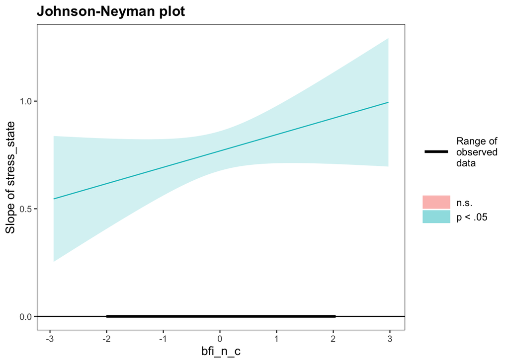

We see from the output and the plot that the within-person *stress reactivity* slopes are significant at all observed values of neuroticism - as we would expect given the non-significance of the interaction term.

We can also probe the 3-way interaction, provided we choose specific values for the 2nd moderator.

```r
#obtaining the standard deviation of the 2nd moderator
describe(daily_long$stress_trait_c)
```

```
##    vars    n  mean   sd median trimmed  mad   min  max range  skew
## X1    1 1458 -0.01 0.47   0.01   -0.01 0.51 -1.21 1.17  2.38 -0.08
##    kurtosis   se
## X1    -0.21 0.01
```

```r
#probing 3-way interaction
# simpleslopes_model2a <- sim_slopes(model=model2a_fit, pred=stress_state, modx=bfi_n_c,
#                                   mod2=stress_trait_c,mod2.values = c(-0.47,+0.47))
# plot(simpleslopes_model2a)
#ran, but did not knit
```

As you try these techniques out with the AMIB data, please let us know if you find a set of variables that has the significant interactions that make for interesting results and theory. =:-]

## Conclusion

This tutorial illustrated application of the basic multilevel model (where the outcome variable is assumed normally distributed - and how interactions are probed and plotted.

**Good luck! =:-]**